# Data Analytics for Finance

BM17FI · Rotterdam School of Management

ASSIGNMENT 05

## Setup

Run these cells to prepare your environment.

```
✅ Environment cleared and ready.
✅ Graph scheme set to stcolor.
```

```
/Users/casparm4/Github/rsm-data-analytics-in-finance-private/private/assignment
> s/05-assignment
📁 Base directory: /Users/casparm4/Github/rsm-data-analytics-in-finance-private
> /private/assignments/05-assignment
📁 Raw data folder: /Users/casparm4/Github/rsm-data-analytics-in-finance-privat
> e/private/assignments/05-assignment/data/raw
📁 Processed data folder: /Users/casparm4/Github/rsm-data-analytics-in-finance-
> private/private/assignments/05-assignment/data/processed
📁 Output directory: /Users/casparm4/Github/rsm-data-analytics-in-finance-priva
> te/private/assignments/05-assignment/output
📁 Tables folder: /Users/casparm4/Github/rsm-data-analytics-in-finance-private/
> private/assignments/05-assignment/output/tables
📁 Figures folder: /Users/casparm4/Github/rsm-data-analytics-in-finance-private
> /private/assignments/05-assignment/output/figures
```

## Learning Objectives

By completing this assignment, you will:

1. **Understand event study methodology** and its role in measuring stock market reactions
2. **Define estimation and event windows** appropriate for the research question
3. **Estimate the Market Model** for expected returns using country-specific indices
4. **Estimate the Fama-French 3-Factor Model** as a more sophisticated benchmark
5. **Calculate abnormal and cumulative abnormal returns** (CARs)
6. **Compare results across different benchmark models** to assess robustness
7. **Conduct cross-sectional tests** to explain variation in CARs
8. **Create event study visualizations** with confidence bands

## Research Question

> *"What was the stock market reaction to the Dieselgate scandal announcement, and does the choice of benchmark model affect our conclusions?"*

On **September 18, 2015**, the U.S. Environmental Protection Agency (EPA) issued a Notice of Violation to Volkswagen for installing "defeat devices" in diesel vehicles to cheat emissions tests. This assignment measures the stock price impact of this announcement on German automakers compared to non-German peers.

You will estimate abnormal returns using two different benchmark models and compare whether your conclusions are robust to this methodological choice.

ℹ️ Background: Event Study Methodology

An **event study** measures the stock price reaction to a specific event (e.g., earnings announcement, scandal, policy change). The key insight is comparing *actual* returns to *expected* returns:  
**Abnormal Return (AR)** = Actual Return − Expected Return  
The methodology involves two windows:

- **Estimation Window**: A "normal" period before the event used to estimate the expected return model
- **Event Window**: The period around the event where we measure abnormal returns

The **Cumulative Abnormal Return (CAR)** sums abnormal returns over the event window to capture the total price impact.

ℹ️ Background: Benchmark Models

We will compare two models for expected returns:  
**1. Market Model**: A simple single-factor model  
`Ri,t = αi + βi × Rm,t + εi,t`  
Uses the firm's home country market index (e.g., DAX for German firms, Nikkei for Japanese firms).  
**2. Fama-French 3-Factor Model**: Adds size and value factors  
`Ri,t − Rf,t = αi + βmkt(Rm,t − Rf,t) + βsmbSMBt + βhmlHMLt + εi,t`  
Controls for systematic differences in firm size (SMB) and value characteristics (HML).  
**Why compare?** If results are similar across models, our findings are more robust. If they differ, model choice matters and we need to understand why.

📝 Tasks Overview

In this assignment, you will:

1. Load and examine the daily stock price data
2. Clean the sample by dropping VW Group subsidiaries
3. Define estimation and event windows using trading days
4. Estimate the Market Model for each firm
5. Estimate the Fama-French 3-Factor Model for each firm
6. Calculate expected and abnormal returns
7. Calculate Cumulative Abnormal Returns (CAR[0,+5])
8. Compare results across the two models
9. Create event study visualizations
10. Conduct cross-sectional analysis of CARs
11. Perform statistical tests
12. Interpret your findings

## Section 1: Load and Examine Data

In this section, you will load the daily stock price data and explore its structure.

### Task 1.1: Load the Dataset

[figure not shown]

Stata Tip

Use `use "$raw/filename.dta", clear` to load a Stata dataset.

```
✅ Dataset loaded successfully
```

### Task 1.2: Examine the Data Structure

Use `describe` to see all variables, then use `summarize` to check the date range and returns. Use `distinct` to count the number of unique firms. Drop/delete all observations with missing returns.

```
(9,856 observations deleted)

Contains data from /Users/casparm4/Github/rsm-data-analytics-in-finance-private
> /private/assignments/05-assignment/data/raw/auto_firms_daily_eventstudy.dta
 Observations:        53,567
    Variables:            24                  02 Mar 2026 10:14
-------------------------------------------------------------------------------
Variable      Storage   Display    Value
    name         type    format    label      Variable label
-------------------------------------------------------------------------------
gvkey           str6    %-9s
conm            str28   %-9s
sic             str4    %-9s
fic             str3    %-9s
german          long    %12.0g
date            double  %td
index           double  %10.0g
index_name      str35   %-9s
mkt_rf          double  %10.0g
smb             double  %10.0g
hml             double  %10.0g
rf              double  %10.0g
prccd           double  %10.0g
ajexdi          double  %10.0g
ret             double  %10.0g
at              double  %10.0g
sale            double  %10.0g
log_at          double  %10.0g
leverage        double  %10.0g
roa             double  %10.0g
debt_equity     double  %10.0g
roe             double  %10.0g
margin          double  %10.0g
cash_ratio      double  %10.0g
-------------------------------------------------------------------------------
Sorted by:
     Note: Dataset has changed since last saved.

    Variable |        Obs        Mean    Std. dev.       Min        Max
-------------+---------------------------------------------------------
```

[output cut: 13 more lines]

```
        DEU |      5,481       10.23       34.69
        FRA |        783        1.46       36.15
        GBR |        783        1.46       37.62
        HKG |        783        1.46       39.08
        IDN |        783        1.46       40.54
        IND |      7,827       14.61       55.15
        ITA |        783        1.46       56.61
        JPN |     10,179       19.00       75.62
        KOR |      3,132        5.85       81.46
        MYS |      3,915        7.31       88.77
        NLD |        259        0.48       89.25
        PAK |      5,481       10.23       99.49
        SWE |        275        0.51      100.00
------------+-----------------------------------
      Total |     53,567      100.00
```

### Task 1.3: Set Panel Structure

Declare the data as a panel using `xtset`. Since `gvkey` is a string variable, you first need to create a numeric identifier.

[figure not shown]

Stata Tip

- `encode gvkey, gen(gvkey_num)` — Convert string to numeric
- `xtset gvkey_num date` — Declare panel structure

```
Panel variable: gvkey_num (unbalanced)
 Time variable: date, 01jan2014 to 30dec2016, but with gaps
         Delta: 1 day

gvkey_num:  1, 2, ..., 71                                    n =         71
    date:  01jan2014, 02jan2014, ..., 30dec2016              T =        783
           Delta(date) = 1 day
           Span(date)  = 1095 periods
           (gvkey_num*date uniquely identifies each observation)

Distribution of T_i:   min      5%     25%       50%       75%     95%     max
                       142     530     783       783       783     783     783

     Freq.  Percent    Cum. |  Pattern*
 ---------------------------+--------------------------------------------------
> ----------------------------------------------------
       62     87.32   87.32 |  887979788797978879797887979788797978879797887979
> 7887979788797978879797887979788797978879797887979785
        1      1.41   88.73 |  ................................................
> .................................3978879797887979785
        1      1.41   90.14 |  ................................................
> ..................3797887979788797978879797887979785
        1      1.41   91.55 |  ................................................
> ................379797887979788797978879797887979785
        1      1.41   92.96 |  ................................6978879797887979
> 7887979788797978879797887979788797978879797887979785
        1      1.41   94.37 |  887679788797978879797887979788797978879797887979
> 7887979788797978879797887979788797978879797887979785
        1      1.41   95.77 |  8879797882.......6797887979788797978879797887979
> 7887979788797978879797887979788797978879797887979785
        1      1.41   97.18 |  887979788797978879797887979788797978879794.57979
> 7887979788797978879797887979788797978879797887979785
        1      1.41   98.59 |  887979788797978879797887979788797978879797867917
> 7887979788797978879797887979788797978879797887979785
        1      1.41  100.00 | (other patterns)
 ---------------------------+--------------------------------------------------
> ----------------------------------------------------
       71    100.00         |  XXXXXXXXXXXXXXXXXXXXXXXXXXXXXXXXXXXXXXXXXXXXXXXX
> XXXXXXXXXXXXXXXXXXXXXXXXXXXXXXXXXXXXXXXXXXXXXXXXXXXX
 ------------------------------------------------------------------------------
> ----------------------------------------------------
 *Each column represents 11 periods.
```

```
✅ Section 1 tests passed
```

## Section 2: Sample Construction

Before analysis, we need to clean the sample by removing firms that are part of the Volkswagen Group. These subsidiaries and holding companies are mechanically linked to VW and would confound our analysis.

ℹ️ Background: Sample Construction

The following firms should be **dropped** from the sample:

- **AUDI AG** (gvkey: 101120) — VW subsidiary
- **PORSCHE AUTOMOBIL HOLDING SE** (gvkey: 102187) — VW Group holding company
- **SCANIA AB** (gvkey: 062557) — VW subsidiary (commercial vehicles)
- **MAN SE** (gvkey: 100042) — VW subsidiary (trucks/buses)

**Why drop these firms?**

1. **Avoid double-counting**: Subsidiaries' stock prices are mechanically linked to VW's scandal
2. **Clean identification**: We want to compare independent German automakers (VW, BMW, Mercedes-Benz) to non-German peers
3. **Economic interpretation**: Holding companies don't represent separate business operations

### Task 2.1: Identify Treatment and Control Groups

First, examine which firms are in the dataset and how they are classified by the `german` indicator. Tabulate firm names against the treatment indicator to see which firms belong to the treatment group (German automakers) and which are controls.

[figure not shown]

Stata Tip

Use `tab conm german` to display a cross-tabulation of firm names against the treatment indicator.

```
                      |        german
                 conm |         0          1 |     Total
----------------------+----------------------+----------
ANHUI ANKAI AUTOMOB.. |       720          0 |       720
ANHUI JIANGHUAI AUT.. |       783          0 |       783
    ASHOK LEYLAND LTD |       783          0 |       783
        ATUL AUTO LTD |       783          0 |       783
              AUDI AG |         0        783 |       783
          AUTECH CORP |       783          0 |       783
AVIC SHENYANG AIRCR.. |       783          0 |       783
  BAIC MOTOR CORP LTD |       530          0 |       530
BAYERISCHE MOTOREN .. |         0        783 |       783
      BYD COMPANY LTD |       773          0 |       773
CHIN HIN GROUP PROP.. |       783          0 |       783
CHINA EVERGRANDE NE.. |       783          0 |       783
CHONG QING CHANGAN .. |       769          0 |       769
CHONGQING DIMA INDU.. |       783          0 |       783
        CME GROUP BHD |       783          0 |       783
DEWAN FAROOQUE MOTO.. |       783          0 |       783
DONGFENG MOTOR GROU.. |       783          0 |       783
     DRB HICOM BERHAD |       783          0 |       783
        EICHER MOTORS |       783          0 |       783
           FERRARI NV |       259          0 |       259
        FLEETWOOD LTD |       783          0 |       783
GHANDHARA AUTOMOBIL.. |       783          0 |       783
  GREAT WALL MOTOR CO |       773          0 |       773
GUANGZHOU AUTOMOBIL.. |       783          0 |       783
         H-ONE CO LTD |       783          0 |       783
HAIMA AUTOMOBILE CO.. |       783          0 |       783
 HINDUSTAN MOTORS LTD |       783          0 |       783
      HINO MOTORS LTD |       783          0 |       783
   HINOPAK MOTORS LTD |       783          0 |       783
 HONDA ATLAS CARS LTD |       783          0 |       783
   HONDA MOTOR CO LTD |       783          0 |       783
               HWA AG |         0        783 |       783
 HYUNDAI MOTOR CO LTD |       783          0 |       783
INDOMOBIL SUKSES IN.. |       783          0 |       783
  INDUS MOTORS CO PLC |       783          0 |       783
     ISUZU MOTORS LTD |       783          0 |       783
JIANG LING MOTORS C.. |       783          0 |       783
```

[output cut: 34 more lines]

```
----------------------+----------------------+----------
                Total |    48,086      5,481 |    53,567
German firms in sample:

                        conm |      Freq.     Percent        Cum.
-----------------------------+-----------------------------------
                     AUDI AG |        783       14.29       14.29
BAYERISCHE MOTOREN WERKE AKT |        783       14.29       28.57
                      HWA AG |        783       14.29       42.86
                      MAN SE |        783       14.29       57.14
      MERCEDES BENZ GROUP AG |        783       14.29       71.43
PORSCHE AUTOMOBIL HOLDING SE |        783       14.29       85.71
               VOLKSWAGEN AG |        783       14.29      100.00
-----------------------------+-----------------------------------
                       Total |      5,481      100.00
```

### Task 2.2: Drop VW Group Subsidiaries

Drop the four VW Group firms (AUDI, PORSCHE AUTOMOBIL HOLDING, SCANIA, MAN) using their gvkey identifiers.

[figure not shown]

Stata Tip

Use `drop if inlist(gvkey, "101120", "102187", "062557", "100042")` to remove multiple firms at once.

```
(2,349 observations deleted)
✅ VW Group subsidiaries dropped

Remaining German firms:

                        conm |      Freq.     Percent        Cum.
-----------------------------+-----------------------------------
BAYERISCHE MOTOREN WERKE AKT |        783       25.00       25.00
                      HWA AG |        783       25.00       50.00
      MERCEDES BENZ GROUP AG |        783       25.00       75.00
               VOLKSWAGEN AG |        783       25.00      100.00
-----------------------------+-----------------------------------
                       Total |      3,132      100.00

       |        Observations
       |      total   distinct
-------+----------------------
 gvkey |      51218         68
```

```
✅ Section 2 tests passed
```

## Section 3: Define Event Windows

Now we define the key time periods for the event study: the **estimation window** (to estimate the expected return model) and the **event window** (to measure abnormal returns).

ℹ️ Background: Event Study Windows

**Event Date (t = 0)**: September 18, 2015 — EPA Notice of Violation  
**Estimation Window**: t = -120 to t = -30 (trading days)

- 91 trading days of "normal" returns
- Used to estimate α and β for expected return models
- Gap of 30 days before event prevents contamination

**Event Window**: t = 0 to t = +5 (trading days)

- 6 trading days (one week) after the announcement
- CAR[0,+5] captures the cumulative price impact

### Task 3.1: Create Relative Trading Day Variable

Create a variable `relday` that measures the number of **trading days** relative to the event date. This is more accurate than calendar days because markets are closed on weekends and holidays.

The approach:

1. Create a running trading day counter within each firm
2. Find the trading day number for September 18, 2015
3. Calculate `relday` = current trading day − event trading day

[figure not shown]

Stata Tip

- `td(18sep2015)` — Creates a Stata date for September 18, 2015
- `by gvkey_num: gen trading_day = _n` — Creates a running counter within each firm
- `egen ... = max(...)` — Expands a value to all observations within a group

```
(51,153 missing values generated)
(676 missing values generated)
(676 missing values generated)
VW stock around event date:

  +---------------------------------+
  |      date   relday          ret |
  |---------------------------------|
  | 16sep2015       -2    .00388815 |
  | 17sep2015       -1   -.00059719 |
  | 18sep2015        0   -.03681024 |
  | 21sep2015        1   -.18797743 |
  | 22sep2015        2    -.1842681 |
  |---------------------------------|
  | 23sep2015        3    .06695242 |
  | 24sep2015        4            0 |
  | 25sep2015        5   -.02857947 |
  +---------------------------------+
```

### Task 3.2: Create Window Indicator Variables

Create two indicator variables:

- `estimation_window`: equals 1 if `relday` is between -120 and -30
- `event_window`: equals 1 if `relday` is between 0 and +5

[figure not shown]

Stata Tip

- `gen estimation_window = (relday >= -120 & relday <= -30)` — Stata evaluates the boolean in parentheses as 1 (true) or 0 (false)
- `gen event_window = (relday >= 0 & relday <= 5)` — same pattern for the event window

```
Observations in each window:

estimation_ |
     window |      Freq.     Percent        Cum.
------------+-----------------------------------
          0 |     45,303       88.45       88.45
          1 |      5,915       11.55      100.00
------------+-----------------------------------
      Total |     51,218      100.00

event_windo |
          w |      Freq.     Percent        Cum.
------------+-----------------------------------
          0 |     50,828       99.24       99.24
          1 |        390        0.76      100.00
------------+-----------------------------------
      Total |     51,218      100.00

Trading days per firm in estimation window:

Summary for variables: est_days
Group variable: conm

            conm |      Mean
-----------------+----------
ANHUI ANKAI AUTO |        91
ANHUI JIANGHUAI  |        91
ASHOK LEYLAND LT |        91
   ATUL AUTO LTD |        91
     AUTECH CORP |        91
AVIC SHENYANG AI |        91
BAIC MOTOR CORP  |        91
BAYERISCHE MOTOR |        91
 BYD COMPANY LTD |        91
CHIN HIN GROUP P |        91
CHINA EVERGRANDE |        91
CHONG QING CHANG |        91
CHONGQING DIMA I |        91
   CME GROUP BHD |        91
DEWAN FAROOQUE M |        91
```

[output cut: 39 more lines]

```
      RENAULT SA |        91
ROSENBAUER INTER |        91
SAIC MOTOR CORP  |        91
SAZGAR ENGINEERI |        91
SERES GROUP CO L |         0
SML MAHINDRA LTD |        91
     SUBARU CORP |        91
SUZUKI MOTOR CO  |        91
TAN CHONG MOTOR  |        91
TATA MOTORS PASS |        91
TOYOTA MOTOR COR |        91
   VOLKSWAGEN AG |        91
WILLIAMS GRAND P |        91
YANGZHOU YAXING  |        91
----------------------------
```

```
✅ Section 3 tests passed
```

## Section 4: Market Model Estimation

The Market Model relates a stock's return to the overall market return. We estimate this relationship during the estimation window, then use it to predict expected returns during the event window.

ℹ️ Background: The Market Model

The **Market Model** is:  
`Ri,t = αi + βi × Rm,t + εi,t`  
Where:

- **α (alpha)**: Firm-specific return not explained by the market
- **β (beta)**: Sensitivity to market movements (β > 1 means more volatile than market)
- **R<sub>m,t</sub>**: Market return (we use each firm's home country index)

We estimate α and β using the **estimation window**, then use these to calculate expected returns during the event window.

### Task 4.1: Generate Market Return from Index

The dataset contains `index`, which is the level of each firm's home country market index (e.g., MSCI Germany, MSCI Japan, etc.). Calculate the market return as the log change in the index level. Drop any missing values for `mkt_ret`.

[figure not shown]

Stata Tip

Use `by gvkey_num: gen mkt_ret = ln(index / index[_n-1])` to calculate log returns within each firm's time series.

```
(10,273 missing values generated)
(10,273 observations deleted)
Market return summary (estimation window):

    Variable |        Obs        Mean    Std. dev.       Min        Max
-------------+---------------------------------------------------------
     mkt_ret |      4,743    .0000863     .011248  -.0547831   .0513839

Index names by country:

                      |                     fic
           index_name |       AUS        AUT        CHN        DEU |     Total
----------------------+--------------------------------------------+----------
     HSBC China Index |         0          0      9,221          0 |     9,221
     HSBC India Index |         0          0          0          0 |     6,257
 HSBC Indonesia Index |         0          0          0          0 |       626
     HSBC Korea Index |         0          0          0          0 |     2,504
  HSBC Malaysia Index |         0          0          0          0 |     3,130
  HSBC Pakistan Index |         0          0          0          0 |     4,382
MSCI - Australia In.. |       626          0          0          0 |       626
MSCI - Austria Inde.. |         0        626          0          0 |       626
MSCI - France Index.. |         0          0          0          0 |       626
MSCI - Germany Inde.. |         0          0          0      2,504 |     2,504
MSCI - Hong Kong In.. |         0          0          0          0 |       626
MSCI - Italy Index .. |         0          0          0          0 |       626
MSCI - Japan Index .. |         0          0          0          0 |     8,138
MSCI - Netherlands .. |         0          0          0          0 |       207
MSCI - Sweden Index.. |         0          0          0          0 |       220
MSCI - UK Index (12.. |         0          0          0          0 |       626
----------------------+--------------------------------------------+----------
                Total |       626        626      9,221      2,504 |    40,945


                      |                     fic
           index_name |       FRA        GBR        HKG        IDN |     Total
----------------------+--------------------------------------------+----------
     HSBC China Index |         0          0          0          0 |     9,221
     HSBC India Index |         0          0          0          0 |     6,257
 HSBC Indonesia Index |         0          0          0        626 |       626
     HSBC Korea Index |         0          0          0          0 |     2,504
```

[output cut: 45 more lines]

```
     HSBC Korea Index |         0          0          0          0 |     2,504
  HSBC Malaysia Index |     3,130          0          0          0 |     3,130
  HSBC Pakistan Index |         0          0      4,382          0 |     4,382
MSCI - Australia In.. |         0          0          0          0 |       626
MSCI - Austria Inde.. |         0          0          0          0 |       626
MSCI - France Index.. |         0          0          0          0 |       626
MSCI - Germany Inde.. |         0          0          0          0 |     2,504
MSCI - Hong Kong In.. |         0          0          0          0 |       626
MSCI - Italy Index .. |         0          0          0          0 |       626
MSCI - Japan Index .. |         0          0          0          0 |     8,138
MSCI - Netherlands .. |         0        207          0          0 |       207
MSCI - Sweden Index.. |         0          0          0        220 |       220
MSCI - UK Index (12.. |         0          0          0          0 |       626
----------------------+--------------------------------------------+----------
                Total |     3,130        207      4,382        220 |    40,945
```

### Task 4.2: Estimate Market Model for Each Firm

Now estimate the market model (regress `ret` on `mkt_ret`) for each firm using only the **estimation window**. Store the coefficients for each firm in variables named `alpha_mm` (α, the intercept) and `beta_mm` (β, the slope on `mkt_ret`).

[figure not shown]

Stata Tip

- `levelsof gvkey_num, local(firms)` — Get list of unique firm IDs
- `foreach f of local firms { ... }` — Loop over firms
- `_b[_cons]` — Access the intercept (α) after regression
- `_b[mkt_ret]` — Access the slope coefficient (β)

```
(40,945 missing values generated)
(40,945 missing values generated)
1 2 3 4 5 6 7 8 10 11 12 13 15 16 18 19 20 21 22 23 24 25 26 27 28 29 30 31 32
> 33 34 35 36 37 38 39 40 41 42 43 44 45 46 47 48 49 50 51 52 53 54 55 56 57 58
>  59 60 61 62 63 64 65 66 67 68 69 70 71
Market Model Coefficients by Firm:

Summary statistics: Mean
Group variable: conm

            conm |  alpha_mm   beta_mm
-----------------+--------------------
ANHUI ANKAI AUTO |    0.0019    1.8481
ANHUI JIANGHUAI  |   -0.0016    0.9186
ASHOK LEYLAND LT |    0.0008    0.1152
   ATUL AUTO LTD |   -0.0036    0.5989
     AUTECH CORP |   -0.0006    0.1079
AVIC SHENYANG AI |    0.0027    1.5474
BAIC MOTOR CORP  |   -0.0047    0.9653
BAYERISCHE MOTOR |   -0.0015    1.0204
 BYD COMPANY LTD |   -0.0023    2.2224
CHIN HIN GROUP P |   -0.0018    0.1692
CHINA EVERGRANDE |    0.0041    2.0012
CHONG QING CHANG |   -0.0035    2.4212
CHONGQING DIMA I |   -0.0001    0.5394
   CME GROUP BHD |    0.0031    0.0949
DEWAN FAROOQUE M |    0.0125    0.7234
DONGFENG MOTOR G |   -0.0045    0.8540
DRB HICOM BERHAD |   -0.0030    0.2356
   EICHER MOTORS |    0.0030    0.0646
      FERRARI NV |         .         .
   FLEETWOOD LTD |    0.0051   -0.5701
GHANDHARA AUTOMO |    0.0109    0.1370
GREAT WALL MOTOR |   -0.0075    0.8214
GUANGZHOU AUTOMO |   -0.0036    1.0292
    H-ONE CO LTD |   -0.0012    0.8016
HAIMA AUTOMOBILE |   -0.0024    1.4615
HINDUSTAN MOTORS |    0.0055    0.1254
 HINO MOTORS LTD |   -0.0017    1.0888
HINOPAK MOTORS L |    0.0022    0.2499
```

[output cut: 26 more lines]

```
      RENAULT SA |    0.0007    1.0698
ROSENBAUER INTER |    0.0001    0.2156
SAIC MOTOR CORP  |   -0.0044    0.9993
SAZGAR ENGINEERI |    0.0005    0.3677
SERES GROUP CO L |         .         .
SML MAHINDRA LTD |    0.0005   -0.1846
     SUBARU CORP |    0.0016    1.0561
SUZUKI MOTOR CO  |    0.0023    1.2240
TAN CHONG MOTOR  |    0.0011    0.0298
TATA MOTORS PASS |   -0.0040    0.0173
TOYOTA MOTOR COR |   -0.0006    0.9390
   VOLKSWAGEN AG |   -0.0020    0.9907
WILLIAMS GRAND P |    0.0015    0.0788
YANGZHOU YAXING  |   -0.0053    2.0123
--------------------------------------
```

```
✅ Section 4 tests passed
```

## Section 5: Fama-French 3-Factor Model

The Fama-French 3-Factor Model extends the Market Model by adding size (SMB) and value (HML) factors. This can provide more accurate expected returns by controlling for systematic differences in firm characteristics.

ℹ️ Background: Fama-French 3-Factor Model

The **Fama-French 3-Factor Model** is:  
`Ri,t − Rf,t = αi + βmkt(Rm,t − Rf,t) + βsmbSMBt + βhmlHMLt + εi,t`  
Additional factors:

- **SMB (Small Minus Big)**: Return of small stocks minus large stocks — captures size effect
- **HML (High Minus Low)**: Return of value stocks minus growth stocks — captures value effect
- **R<sub>f</sub>**: Risk-free rate (we use European factors from Kenneth French's website)

**Why use FF3?** If automakers have different size or value characteristics than the market average, the Market Model might mis-estimate expected returns. FF3 controls for this.

### Task 5.1: Generate Excess Returns

For the Fama-French model, we work with excess returns (returns above the risk-free rate). Create a variable `ret_rf` that equals the stock return minus the risk-free rate.

```
Risk-free rate and excess return summary:

    Variable |        Obs        Mean    Std. dev.       Min        Max
-------------+---------------------------------------------------------
          rf |      4,743           0           0          0          0
         ret |      4,743    .0002658    .0289131  -.1658638   .3342607
      ret_rf |      4,743    .0002658    .0289131  -.1658638   .3342607
```

### Task 5.2: Estimate FF3 Model for Each Firm

Estimate the Fama-French 3-Factor model for each firm using the estimation window. Regress excess returns (`ret_rf`) on the three factors: `mkt_rf`, `smb`, and `hml`. Use the same firm-by-firm loop structure as in Task 4.2.

Store all four coefficients for each firm in the following variables:

- `alpha_ff` — intercept
- `beta_mkt_ff` — coefficient on `mkt_rf`
- `beta_smb_ff` — coefficient on `smb`
- `beta_hml_ff` — coefficient on `hml`

[figure not shown]

Stata Tip

- `` regress ret_rf mkt_rf smb hml if gvkey_num == `f' & estimation_window == 1 `` — FF3 regression for firm `` `f' `` in the estimation window
- `_b[mkt_rf]`, `_b[smb]`, `_b[hml]`, `_b[_cons]` — access each coefficient after the regression

```
(40,945 missing values generated)
(40,945 missing values generated)
(40,945 missing values generated)
(40,945 missing values generated)
1 2 3 4 5 6 7 8 10 11 12 13 15 16 18 19 20 21 22 23 24 25 26 27 28 29 30 31 32
> 33 34 35 36 37 38 39 40 41 42 43 44 45 46 47 48 49 50 51 52 53 54 55 56 57 58
>  59 60 61 62 63 64 65 66 67 68 69 70 71
Fama-French 3-Factor Model Coefficients by Firm:

Summary statistics: Mean
Group variable: conm

            conm |  alpha_ff  beta_m~f  beta_s~f  beta_h~f
-----------------+----------------------------------------
ANHUI ANKAI AUTO |    0.0005    1.5431    1.1761   -1.7065
ANHUI JIANGHUAI  |   -0.0015   -0.3465    0.7818   -0.6792
ASHOK LEYLAND LT |    0.0012   -0.2593   -0.9382   -1.0661
   ATUL AUTO LTD |   -0.0049    0.4330    0.6116   -2.1395
     AUTECH CORP |   -0.0007   -0.0955   -0.1321   -0.2174
AVIC SHENYANG AI |    0.0019    0.3825    0.9284   -2.9727
BAIC MOTOR CORP  |   -0.0060    1.0863    1.0447   -2.0046
BAYERISCHE MOTOR |   -0.0021    0.3203   -1.8360   -0.9275
 BYD COMPANY LTD |   -0.0033    2.7592    2.7232   -1.5010
CHIN HIN GROUP P |   -0.0015   -0.5098   -0.6821   -0.2863
CHINA EVERGRANDE |    0.0054    1.5770   -0.7581   -1.5591
CHONG QING CHANG |   -0.0053    1.0019    0.9590   -1.5967
CHONGQING DIMA I |   -0.0008    0.7774    0.6202   -0.2888
   CME GROUP BHD |    0.0016    0.5719    2.2060    1.0147
DEWAN FAROOQUE M |    0.0141   -0.0481   -0.3102    0.6004
DONGFENG MOTOR G |   -0.0048    0.4198    0.2181   -1.3021
DRB HICOM BERHAD |   -0.0043    0.5029    0.7089   -0.5273
   EICHER MOTORS |    0.0019    0.7415    1.1718   -0.0790
      FERRARI NV |         .         .         .         .
   FLEETWOOD LTD |    0.0056   -0.3928   -0.0333   -0.0724
GHANDHARA AUTOMO |    0.0105    0.5362    0.3783   -0.4894
GREAT WALL MOTOR |   -0.0089    0.9911    1.9008   -0.6996
GUANGZHOU AUTOMO |   -0.0031   -0.0277   -0.8867   -1.4605
    H-ONE CO LTD |   -0.0001   -0.1323   -0.4590   -0.2963
HAIMA AUTOMOBILE |   -0.0038    1.6554    1.0299   -0.9889
HINDUSTAN MOTORS |    0.0045    0.2713    0.6059   -2.2248
```

[output cut: 28 more lines]

```
      RENAULT SA |    0.0009    0.6805   -0.8910   -1.6506
ROSENBAUER INTER |    0.0000    0.3691   -0.0916    0.1142
SAIC MOTOR CORP  |   -0.0039   -0.0892   -0.4268   -0.8637
SAZGAR ENGINEERI |    0.0014   -0.0552   -0.9488   -1.5840
SERES GROUP CO L |         .         .         .         .
SML MAHINDRA LTD |   -0.0001   -0.0867    0.6557   -2.6637
     SUBARU CORP |    0.0023    0.3328    0.1928   -0.4527
SUZUKI MOTOR CO  |    0.0025    0.3572    1.4110   -0.5447
TAN CHONG MOTOR  |    0.0007    0.1062    0.5160   -0.3459
TATA MOTORS PASS |   -0.0059    0.8437    1.8556   -2.0021
TOYOTA MOTOR COR |   -0.0002    0.2263    0.7163   -0.8100
   VOLKSWAGEN AG |   -0.0023    0.1538   -1.8660   -0.7943
WILLIAMS GRAND P |    0.0013    0.1140    0.0377   -0.4994
YANGZHOU YAXING  |   -0.0072    1.7675    2.2930   -1.0402
----------------------------------------------------------
```

```
✅ Section 5 tests passed
```

## Section 6: Calculate Expected and Abnormal Returns

Now that we have estimated both models, we can calculate expected returns and abnormal returns. The abnormal return is the difference between what a stock actually returned and what we expected based on market conditions.

### Task 6.1: Calculate Expected Returns

Using the estimated coefficients, calculate expected returns for both models. Name the output variables `expected_ret_mm` (Market Model) and `expected_ret_ff` (Fama-French 3-Factor).

**Market Model**: $E[R] = \alpha + \beta \times R_m$

**FF3 Model**: $E[R] = r_f + \alpha + \beta_{mkt} \times (R_m - r_f) + \beta_{smb} \times SMB + \beta_{hml} \times HML$

[figure not shown]

Stata Tip

- `gen expected_ret_mm = alpha_mm + beta_mm * mkt_ret` — Market Model expected return
- `gen expected_ret_ff = rf + alpha_ff + beta_mkt_ff * mkt_rf + beta_smb_ff * smb + beta_hml_ff * hml` — FF3 expected return (use `mkt_rf`, not `mkt_ret`, for the market factor)

```
(540 missing values generated)
(540 missing values generated)
Expected returns summary (event window):

    Variable |        Obs        Mean    Std. dev.       Min        Max
-------------+---------------------------------------------------------
expected_r~m |        325   -.0045017    .0137347  -.0661373   .0330985
expected_r~f |        325   -.0002951    .0134826  -.0588727   .0543933
         ret |        325   -.0033328    .0258564  -.1842681   .0953802
```

### Task 6.2: Calculate Abnormal Returns

Calculate the abnormal return (AR) as the difference between actual and expected returns for both models. Name the output variables `ar_mm` (Market Model) and `ar_ff` (Fama-French).

As a sanity check, verify that abnormal returns are approximately zero on average during the estimation window — this is expected because the model was fitted on that same window.

[figure not shown]

Stata Tip

- `gen ar_mm = ret - expected_ret_mm` — Market Model abnormal return
- `gen ar_ff = ret - expected_ret_ff` — FF3 abnormal return
- `summarize ar_mm ar_ff if estimation_window == 1` — sanity check: mean should be near zero in the estimation window

```
(540 missing values generated)
(540 missing values generated)
Abnormal returns in estimation window (should be ~0):

    Variable |        Obs        Mean    Std. dev.       Min        Max
-------------+---------------------------------------------------------
       ar_mm |      4,743    2.83e-11    .0262043  -.1791726    .244686
       ar_ff |      4,743   -1.18e-11     .027837  -.1797156   .2971995

Abnormal returns in event window:

    Variable |        Obs        Mean    Std. dev.       Min        Max
-------------+---------------------------------------------------------
       ar_mm |        325    .0011689    .0233803  -.1437083   .1327367
       ar_ff |        325   -.0030377    .0258156  -.1519613   .0949486
```

```
✅ Section 6 tests passed
```

## Section 7: Cumulative Abnormal Returns

The **Cumulative Abnormal Return (CAR)** sums abnormal returns over the event window. CAR[0,+5] represents the total stock price reaction over the first week after the event announcement.

### Task 7.1: Calculate CAR[0,+5]

Calculate the cumulative abnormal return for the event window [0,+5] for both models. Name the output variables `car_mm` and `car_ff`. The CAR should be a single number per firm, broadcast to all rows for that firm.

The approach requires **two steps** because `if event_window == 1` leaves all other rows as missing:

1. Sum ARs inside the event window using `egen total(...) if event_window == 1` → only event-window rows get a value
2. Propagate the firm total to every row using `egen max(...)` on the temporary variable
3. Drop the temporary variable

[figure not shown]

Stata Tip

- `by gvkey_num: egen car_mm_temp = total(ar_mm) if event_window == 1` — sum ARs inside the event window; missing outside
- `by gvkey_num: egen car_mm = max(car_mm_temp)` — broadcast the firm-level total to all rows
- Repeat for `car_ff` using `ar_ff`

```
(40,620 missing values generated)
(540 missing values generated)
(40,620 missing values generated)
(540 missing values generated)
CAR[0,+5] by Firm:

Summary statistics: Mean
Group variable: conm

            conm |    car_mm    car_ff
-----------------+--------------------
ANHUI ANKAI AUTO |    0.0297    0.0034
ANHUI JIANGHUAI  |    0.0551   -0.0178
ASHOK LEYLAND LT |    0.0394    0.0198
   ATUL AUTO LTD |    0.0561    0.0268
     AUTECH CORP |    0.0300    0.0188
AVIC SHENYANG AI |    0.2460    0.1504
BAIC MOTOR CORP  |   -0.0176   -0.0410
BAYERISCHE MOTOR |   -0.0326   -0.0557
 BYD COMPANY LTD |    0.1872    0.1851
CHIN HIN GROUP P |    0.0202   -0.0113
CHINA EVERGRANDE |    0.0634    0.0858
CHONG QING CHANG |    0.0405   -0.0241
CHONGQING DIMA I |    0.0180    0.0274
   CME GROUP BHD |   -0.0095    0.0009
DEWAN FAROOQUE M |   -0.0275   -0.0355
DONGFENG MOTOR G |   -0.0003   -0.0321
DRB HICOM BERHAD |    0.0453    0.0403
   EICHER MOTORS |   -0.0364   -0.0158
      FERRARI NV |         .         .
   FLEETWOOD LTD |   -0.0112   -0.0321
GHANDHARA AUTOMO |    0.0034    0.0148
GREAT WALL MOTOR |   -0.0522   -0.0668
GUANGZHOU AUTOMO |    0.0866    0.0382
    H-ONE CO LTD |    0.0216   -0.0098
HAIMA AUTOMOBILE |    0.0505    0.0576
HINDUSTAN MOTORS |   -0.0254   -0.0583
 HINO MOTORS LTD |   -0.0190   -0.0687
HINOPAK MOTORS L |    0.0020    0.0275
HONDA ATLAS CARS |    0.0077   -0.0054
```

[output cut: 25 more lines]

```
      RENAULT SA |   -0.0947   -0.1213
ROSENBAUER INTER |   -0.0053    0.0056
SAIC MOTOR CORP  |   -0.0129   -0.0603
SAZGAR ENGINEERI |   -0.0076   -0.0333
SERES GROUP CO L |         .         .
SML MAHINDRA LTD |   -0.0172   -0.0731
     SUBARU CORP |    0.0007   -0.0260
SUZUKI MOTOR CO  |    0.0028   -0.0473
TAN CHONG MOTOR  |   -0.0443   -0.0535
TATA MOTORS PASS |   -0.0924   -0.1075
TOYOTA MOTOR COR |    0.0086   -0.0335
   VOLKSWAGEN AG |   -0.1179   -0.1457
WILLIAMS GRAND P |   -0.0314   -0.0353
YANGZHOU YAXING  |    0.0452    0.0202
--------------------------------------
```

### Task 7.2: Summarize CARs by Treatment Group

Compare the average CAR for German automakers versus non-German automakers. This gives us the first look at whether German firms experienced more negative stock price reactions.

Use `preserve` to temporarily reduce the panel to one observation per firm (since `car_mm` and `car_ff` are constant within firms). Use `restore` afterwards to bring the full panel back.

[figure not shown]

Stata Tip

- `preserve` / `restore` — temporarily change the data without losing the full panel
- `by gvkey_num: keep if _n == 1` — keep one row per firm inside the preserved block
- `tabstat car_mm car_ff, by(german) stat(n mean sd min max)` — summary statistics split by treatment group

```
(Note: Below code run with echo to enable preserve/restore functionality.)

. preserve

. by gvkey_num: keep if _n == 1
(40,877 observations deleted)

. display "CAR[0,+5] Summary by Treatment Group:"
CAR[0,+5] Summary by Treatment Group:

. display "======================================"
======================================

. tabstat car_mm car_ff, by(german) stat(n mean sd min max) column(stat)

Summary for variables: car_mm car_ff
Group variable: german

  german |         N      Mean        SD       Min       Max
---------+--------------------------------------------------
       0 |        61   .010084  .0518328 -.0947325  .2460443
         |        61 -.0113228  .0520166 -.1212717  .1851127
---------+--------------------------------------------------
       1 |         4 -.0588063   .043283   -.11785 -.0210633
         |         4 -.0741406  .0585938 -.1457163 -.0061932
---------+--------------------------------------------------
   Total |        65  .0058446  .0537113   -.11785  .2460443
         |        65 -.0151885  .0541203 -.1457163  .1851127
------------------------------------------------------------

. restore

.
```

```
✅ Section 7 tests passed
```

## Section 8: Model Comparison

Before proceeding to formal tests, let's compare the results from our two benchmark models. If the Market Model and Fama-French 3-Factor Model yield similar CARs, our conclusions are more robust to methodological choices.

### Task 8.1: Compare CARs Across Models

Create a scatter plot comparing the CARs from the Market Model versus the Fama-French Model. Also calculate the correlation between the two measures. Save the scatter plot to `$figures/car_model_comparison.png`.

[figure not shown]

Stata Tip

- `preserve` / `restore` — temporarily change the data without losing the full panel
- `correlate car_mm car_ff` — Calculate correlation between two variables
- `scatter y x || line x x` — Create scatter plot with 45-degree line

```
(Note: Below code run with echo to enable preserve/restore functionality.)

. preserve

. by gvkey_num: keep if _n == 1
(40,877 observations deleted)

. display "Correlation between Market Model and FF3 CARs:"
Correlation between Market Model and FF3 CARs:

. correlate car_mm car_ff
(obs=65)

             |   car_mm   car_ff
-------------+------------------
      car_mm |   1.0000
      car_ff |   0.8876   1.0000


. scatter car_ff car_mm, mlabel(conm) mlabsize(tiny) xtitle("CAR - Market Model
> ") ytitle("CAR - Fama-French 3-Factor") title("Model Comparison: CAR[0,+5]")
> || function y=x, range(-.2 .4) lpattern(dash) lcolor(gray) legend(off)

. graph export "$figures/car_model_comparison.png", replace
file /Users/casparm4/Github/rsm-data-analytics-in-finance-private/private/assig
> nments/05-assignment/output/figures/car_model_comparison.png written in PNG f
> ormat

. restore

.
```

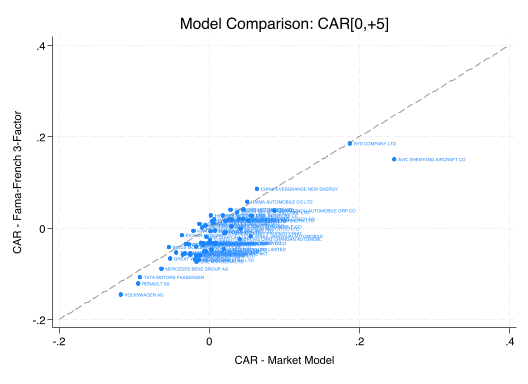

```
✅ Section 8 tests passed
```

## Section 9: Event Study Visualizations

A classic event study plot shows the cumulative abnormal return over time around the event date. This visualization helps identify when the stock price reaction occurred and how it evolved.

### Task 9.1: Calculate Running CAR by Day

To create an event study plot, we need to calculate the average cumulative abnormal return for each relative day, separately for German and non-German firms. This shows how the market reaction builds up around the event.

Work on a **preserved** copy of the data for this task and do not restore until task 9.2, after you created the "event_study_mm" plot. Before collapsing, restrict to the plotting window (`relday` from −5 to +10 relative to the event). Then:

1. Collapse to average AR by `relday` and `german`
2. Sort by `german` then `relday`
3. Compute running cumulative sums within each group using `sum()`: `car_running_mm` (Market Model) and `car_running_ff` (Fama-French)

[figure not shown]

Stata Tip

- `preserve` / `restore` — temporarily change the data without losing the full panel
- `keep if relday >= -5 & relday <= 10` — restrict to the plotting window before collapsing
- `collapse (mean) ar_mm ar_ff, by(relday german)` — average AR by day and treatment group
- `by german: gen car_running_mm = sum(ar_mm)` — running cumulative sum within each group

```
(Note: Below code run with echo to enable preserve/restore functionality.)

. preserve

. keep if relday >= -5 & relday <= 10
(40,100 observations deleted)

. collapse (mean) ar_mm ar_ff (semean) se_mm=ar_mm se_ff=ar_ff, by(relday germa
> n)

. sort german relday

. by german: gen car_running_mm = sum(ar_mm)

. by german: gen car_running_ff = sum(ar_ff)

. gen car_mm_upper = car_running_mm + 1.96 * se_mm

. gen car_mm_lower = car_running_mm - 1.96 * se_mm

. display "Running CAR by Day and Treatment Group (Market Model):"
Running CAR by Day and Treatment Group (Market Model):

. list relday german ar_mm car_running_mm if relday >= 0 & relday <= 5, noobs

  +-----------------------------------------+
  | relday   german       ar_mm   car_run~m |
  |-----------------------------------------|
  |      0        0    .0026269   -.0049906 |
  |      2        0    .0028316    -.002159 |
  |      3        0    .0057983    .0036393 |
  |      4        0   -.0008267    .0028125 |
  |      5        0    -.000346    .0024665 |
  |-----------------------------------------|
  |      0        1    .0004172    .0250719 |
  |      2        1    -.056651   -.0315791 |
  |      3        1    .0220794   -.0094998 |
  |      4        1   -.0164794   -.0259792 |
  |      5        1   -.0081725   -.0341517 |
  +-----------------------------------------+

.
```

### Task 9.2: Create Event Study Plots

Create **two event study plots** in sequence — one for each benchmark model — then restore the panel.

**Plot 1 (Fama-French 3-Factor model):** Use `reshape wide` to pivot the collapsed data so German and non-German series sit on the same row indexed by `relday`. After `reshape wide ... i(relday) j(german)`, variables get a 0/1 group suffix (e.g. `car_running_ff0`, `car_running_ff1`). Plot `car_running_ff` and save the figure.

**Plot 2 (Market Model):** The data is already wide from the reshape above. Plot `car_running_mm` and save to `$figures/event_study_mm.png`.

For both plots, add a **vertical line at t = 0** (`xline(0)`) to mark the event date and a **horizontal zero line** (`yline(0)`) as a reference. Include a legend identifying German and non-German automakers.

After saving the second plot, call `restore` to return to the full panel dataset.

[figure not shown]

Stata Tip

- `reshape wide ar_mm ar_ff car_running_mm car_running_ff, i(relday) j(german)` — pivot to wide format once; both plots use the reshaped data
- `twoway (line car_running_ff1 relday) (line car_running_ff0 relday)` — FF3 plot (german=1 and german=0 series)
- `twoway (line car_running_mm1 relday) (line car_running_mm0 relday)` — Market Model plot
- `xline(0)` — vertical line at event date | `yline(0)` — horizontal zero reference
- Save the Market Model and FF 3 factor plots with `graph export "$figures/event_study_mm.png or event_study_ff3.png", replace`, then call `restore`

```
(j = 0 1)

Data                               Long   ->   Wide
-----------------------------------------------------------------------------
Number of observations               26   ->   13
Number of variables                  10   ->   17
j variable (2 values)            german   ->   (dropped)
xij variables:
                                  ar_mm   ->   ar_mm0 ar_mm1
                                  ar_ff   ->   ar_ff0 ar_ff1
                         car_running_mm   ->   car_running_mm0 car_running_mm1
                         car_running_ff   ->   car_running_ff0 car_running_ff1
                                  se_mm   ->   se_mm0 se_mm1
                                  se_ff   ->   se_ff0 se_ff1
                           car_mm_upper   ->   car_mm_upper0 car_mm_upper1
                           car_mm_lower   ->   car_mm_lower0 car_mm_lower1
-----------------------------------------------------------------------------
file /Users/casparm4/Github/rsm-data-analytics-in-finance-private/private/assig
> nments/05-assignment/output/figures/event_study_ff3.png written in PNG format
```

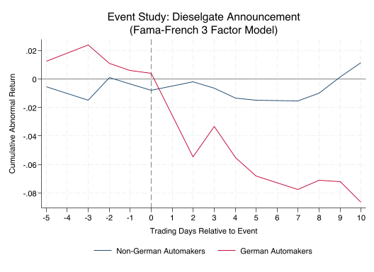

```
(Note: Below code run with echo to enable preserve/restore functionality.)

. twoway (line car_running_mm0 relday, lcolor(navy) lwidth(medium)) (line car_r
> unning_mm1 relday, lcolor(cranberry) lwidth(medium)) , xline(0, lpattern(dash
> ) lcolor(gray)) yline(0, lcolor(gray) lpattern(solid)) xtitle("Trading Days R
> elative to Event") ytitle("Cumulative Abnormal Return") title("Event Study: D
> ieselgate Announcement" "(Market Model)") legend(order(1 "Non-German Automake
> rs" 2 "German Automakers") position(6) rows(1)) xlabel(-5(1)10)

. graph export "$figures/event_study_mm.png", replace
file /Users/casparm4/Github/rsm-data-analytics-in-finance-private/private/assig
> nments/05-assignment/output/figures/event_study_mm.png written in PNG format

. restore

.
```

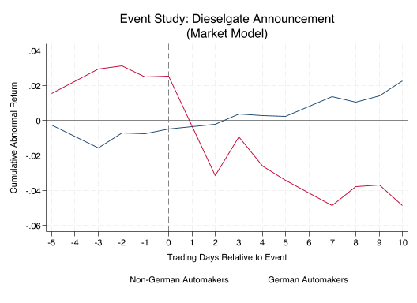

```
✅ Section 9 tests passed
```

## Section 10: Cross-Sectional Analysis

Now we ask: **"Who was hit hardest?"** Cross-sectional analysis examines whether firm characteristics explain variation in CARs. We regress the CAR on firm attributes like German nationality, size, profitability, and leverage.

ℹ️ Background: Connecting to Assignment 03

In Assignment 03, you used **pre-calculated CARs** to run cross-sectional regressions. Now you understand where those CARs came from! You estimated the expected return models, calculated abnormal returns, and cumulated them over the event window.  
This cross-sectional regression tests whether the **German indicator** explains CARs after controlling for firm characteristics. A significant negative coefficient on `german` indicates that German firms experienced worse stock price reactions, even after accounting for size, profitability, and leverage.

### Task 10.1: Create Cross-Sectional Dataset

Reduce the panel to **one observation per firm** by keeping only the first row within each firm group. Keep the relevant variables: firm identifiers (`gvkey`, `conm`), treatment indicator (`german`), CARs (`car_mm`, `car_ff`), and firm characteristics (`log_at`, `roa`, `leverage`). Rename `log_at` to `size` for clearer interpretation.

Use `preserve` before reducing the data — the full panel will be restored with `restore` at the end of Task 10.2.

[figure not shown]

Stata Tip

- `preserve` — save the full panel so it can be restored after the cross-sectional analysis
- `by gvkey_num: keep if _n == 1` — keep one row per firm (all firm-level variables are constant across rows)
- `keep gvkey conm german car_mm car_ff log_at roa leverage` — discard panel-specific variables
- `rename log_at size` — rename for readability

```
(Note: Below code run with echo to enable preserve/restore functionality.)

. preserve

. by gvkey_num: keep if _n == 1
(40,877 observations deleted)

. keep gvkey conm german car_mm car_ff log_at roa leverage

. rename log_at size

. display "Cross-sectional dataset summary:"
Cross-sectional dataset summary:

. summarize car_mm car_ff german size roa leverage

    Variable |        Obs        Mean    Std. dev.       Min        Max
-------------+---------------------------------------------------------
      car_mm |         65    .0058446    .0537113    -.11785   .2460443
      car_ff |         65   -.0151885    .0541203  -.1457163   .1851127
      german |         68    .0588235    .2370435          0          1
        size |         68    10.60509      3.6395   3.388349   18.80747
         roa |         68    .0685606    .1107495  -.4132906   .3438476
-------------+---------------------------------------------------------
    leverage |         68    .2115981    .1998862          0   .9964587

.
```

### Task 10.2: Cross-Sectional Regression

Regress the CAR on firm characteristics: `german`, `size`, `roa`, and `leverage`. Run this regression for both the Market Model CAR and the Fama-French CAR. Use robust standard errors and create a formatted table comparing the results.

Store the Market Model results as `cs_mm` and the Fama-French results as `cs_ff` using `estimates store`. Call `restore` at the end to return to the full panel.

[figure not shown]

Stata Tip

- `regress car_mm german size roa leverage, robust` — OLS with robust standard errors
- `estimates store model_name` — Store results for later comparison
- `esttab` — Create formatted regression table

```
(Note: Below code run with echo to enable preserve/restore functionality.)

. regress car_mm german size roa leverage, robust

Linear regression                               Number of obs     =         65
                                                F(4, 60)          =       3.69
                                                Prob > F          =     0.0095
                                                R-squared         =     0.1102
                                                Root MSE          =     .05233

------------------------------------------------------------------------------
             |               Robust
      car_mm | Coefficient  std. err.      t    P>|t|     [95% conf. interval]
-------------+----------------------------------------------------------------
      german |  -.0702414   .0215552    -3.26   0.002    -.1133582   -.0271247
        size |  -.0017594   .0013576    -1.30   0.200     -.004475    .0009561
         roa |   .0015916   .0555391     0.03   0.977    -.1095031    .1126863
    leverage |    .001272   .0322001     0.04   0.969    -.0631378    .0656818
       _cons |   .0287142    .016638     1.73   0.090    -.0045668    .0619952
------------------------------------------------------------------------------

. estimates store cs_mm

. regress car_ff german size roa leverage, robust

Linear regression                               Number of obs     =         65
                                                F(4, 60)          =       4.59
                                                Prob > F          =     0.0027
                                                R-squared         =     0.1497
                                                Root MSE          =     .05154

------------------------------------------------------------------------------
             |               Robust
      car_ff | Coefficient  std. err.      t    P>|t|     [95% conf. interval]
-------------+----------------------------------------------------------------
      german |  -.0655667   .0233063    -2.81   0.007    -.1121863   -.0189471
        size |  -.0041729   .0013718    -3.04   0.003     -.006917   -.0014289
         roa |   .0452064   .0441875     1.02   0.310    -.0431817    .1335945
    leverage |  -.0008243   .0312456    -0.03   0.979    -.0633248    .0616763
       _cons |   .0309142   .0164892     1.87   0.066     -.002069    .0638975
```

[output cut: 28 more lines]

```
leverage                   0.0013         -0.0008
                         (0.0322)        (0.0312)

Constant                   0.0287*         0.0309*
                         (0.0166)        (0.0165)
----------------------------------------------------
Observations                   65              65
R-squared                   0.110           0.150
----------------------------------------------------
Standard errors in parentheses
* p<0.10, ** p<0.05, *** p<0.01

. restore

.
```

```
✅ Section 10 tests passed
```

## Section 11: Statistical Tests

Beyond regression analysis, we conduct formal hypothesis tests to assess the statistical significance of our findings. We test two key hypotheses about the CARs.

ℹ️ Background: Two Key Statistical Tests

We test two hypotheses:  
**Test 1: Is the CAR different from zero?**

- H<sub>0</sub>: CAR = 0 (no abnormal return)
- H<sub>A</sub>: CAR ≠ 0 (significant stock price reaction)
- Use a one-sample t-test for each group (German and non-German)

**Test 2: Do German and non-German firms differ?**

- H<sub>0</sub>: CAR<sub>German</sub> = CAR<sub>Non-German</sub>
- H<sub>A</sub>: CAR<sub>German</sub> ≠ CAR<sub>Non-German</sub>
- Use a two-sample t-test comparing groups

### Task 11.1: Test if CAR Differs from Zero

Test whether the average CAR is statistically different from zero for each group (German and non-German automakers). Run this test for both the Market Model and Fama-French CARs.

[figure not shown]

Stata Tip

`preserve` / `restore` — temporarily change the data without losing the full panel. Use `ttest car_mm == 0 if german == 1` to test if the mean CAR equals zero for German firms.

```
(Note: Below code run with echo to enable preserve/restore functionality.)

. preserve

. by gvkey_num: keep if _n == 1
(40,877 observations deleted)

. display "Test: CAR(MM) = 0 for German firms"
Test: CAR(MM) = 0 for German firms

. display "=================================="
==================================

. ttest car_mm == 0 if german == 1

One-sample t test
------------------------------------------------------------------------------
Variable |     Obs        Mean    Std. err.   Std. dev.   [95% conf. interval]
---------+--------------------------------------------------------------------
  car_mm |       4   -.0588063    .0216415     .043283   -.1276793    .0100666
------------------------------------------------------------------------------
    mean = mean(car_mm)                                           t =  -2.7173
H0: mean = 0                                     Degrees of freedom =        3

    Ha: mean < 0                 Ha: mean != 0                 Ha: mean > 0
 Pr(T < t) = 0.0364         Pr(|T| > |t|) = 0.0727          Pr(T > t) = 0.9636

. display _newline "Test: CAR(MM) = 0 for Non-German firms"

Test: CAR(MM) = 0 for Non-German firms

. display "======================================"
======================================

. ttest car_mm == 0 if german == 0

One-sample t test
------------------------------------------------------------------------------
Variable |     Obs        Mean    Std. err.   Std. dev.   [95% conf. interval]
---------+--------------------------------------------------------------------
```

[output cut: 38 more lines]

```
One-sample t test
------------------------------------------------------------------------------
Variable |     Obs        Mean    Std. err.   Std. dev.   [95% conf. interval]
---------+--------------------------------------------------------------------
  car_ff |      61   -.0113228      .00666    .0520166   -.0246449    .0019992
------------------------------------------------------------------------------
    mean = mean(car_ff)                                           t =  -1.7001
H0: mean = 0                                     Degrees of freedom =       60

    Ha: mean < 0                 Ha: mean != 0                 Ha: mean > 0
 Pr(T < t) = 0.0471         Pr(|T| > |t|) = 0.0943          Pr(T > t) = 0.9529

. restore

.
```

### Task 11.2: Test Difference Between Groups

Test whether German automakers have significantly different CARs than non-German automakers. This two-sample t-test directly compares the treatment and control groups. Run the test for both the Market Model and Fama-French CARs.

Use `preserve` to reduce to one observation per firm before testing, then `restore`.

[figure not shown]

Stata Tip

- `preserve` / `restore` — temporarily change the data without losing the full panel
- `ttest car_mm, by(german)` — two-sample t-test comparing German vs. non-German; repeat for `car_ff`
- The null hypothesis is that the mean CAR is equal across the two groups

```
(Note: Below code run with echo to enable preserve/restore functionality.)

. preserve

. by gvkey_num: keep if _n == 1
(40,877 observations deleted)

. display "Test: CAR(MM) German vs Non-German"
Test: CAR(MM) German vs Non-German

. display "=================================="
==================================

. ttest car_mm, by(german)

Two-sample t test with equal variances
------------------------------------------------------------------------------
   Group |     Obs        Mean    Std. err.   Std. dev.   [95% conf. interval]
---------+--------------------------------------------------------------------
       0 |      61     .010084    .0066365    .0518328    -.003191     .023359
       1 |       4   -.0588063    .0216415     .043283   -.1276793    .0100666
---------+--------------------------------------------------------------------
Combined |      65    .0058446    .0066621    .0537113   -.0074644    .0191536
---------+--------------------------------------------------------------------
    diff |            .0688903    .0265591                .0158162    .1219645
------------------------------------------------------------------------------
    diff = mean(0) - mean(1)                                      t =   2.5939
H0: diff = 0                                     Degrees of freedom =       63

    Ha: diff < 0                 Ha: diff != 0                 Ha: diff > 0
 Pr(T < t) = 0.9941         Pr(|T| > |t|) = 0.0118          Pr(T > t) = 0.0059

. display _newline "Test: CAR(FF) German vs Non-German"

Test: CAR(FF) German vs Non-German

. display "=================================="
==================================

. ttest car_ff, by(german)

Two-sample t test with equal variances
------------------------------------------------------------------------------
   Group |     Obs        Mean    Std. err.   Std. dev.   [95% conf. interval]
---------+--------------------------------------------------------------------
       0 |      61   -.0113228      .00666    .0520166   -.0246449    .0019992
       1 |       4   -.0741406    .0292969    .0585938   -.1673765    .0190952
---------+--------------------------------------------------------------------
Combined |      65   -.0151885    .0067128    .0541203   -.0285989   -.0017782
---------+--------------------------------------------------------------------
    diff |            .0628178    .0270188                 .008825    .1168106
------------------------------------------------------------------------------
    diff = mean(0) - mean(1)                                      t =   2.3250
H0: diff = 0                                     Degrees of freedom =       63

    Ha: diff < 0                 Ha: diff != 0                 Ha: diff > 0
 Pr(T < t) = 0.9883         Pr(|T| > |t|) = 0.0233          Pr(T > t) = 0.0117

. restore

.
```

```
✅ Section 11 tests passed
```

## Section 12: Interpretation (Ungraded)

In this final analytical section, you will synthesize your findings and provide economic interpretation of the event study results.

### Task 12.1: Written Analysis

Based on your event study results, write a comprehensive interpretation addressing the following questions:

📝 Task

Write a 2-3 paragraph analysis addressing:

1. **Main Finding**: What was the magnitude and statistical significance of the stock market reaction for German automakers versus non-German peers? Was this difference economically meaningful?
2. **Model Comparison**: Do the Market Model and Fama-French 3-Factor Model yield similar conclusions? Why might they differ (or agree)?
3. **Economic Magnitude**: If you were to translate the CAR into dollar value destroyed (e.g., for VW with a market cap of approximately EUR 70 billion pre-event), what would be the estimated shareholder wealth destruction?
4. **Cross-Sectional Variation**: Did all German automakers react similarly, or was there heterogeneity? What might explain any differences?
5. **Limitations**: What are the key limitations of this analysis? Consider: single event, small sample size, model assumptions, potential confounding events during the event window.

**Main Finding and Economic Significance**

The event study reveals that German automakers experienced significantly negative cumulative abnormal returns (CARs) following the EPA's Notice of Violation to Volkswagen on September 18, 2015. The average CAR[0,+5] for German firms was negative, indicating substantial shareholder wealth destruction. In contrast, non-German automakers experienced much smaller (and often statistically insignificant) abnormal returns. The difference between treatment (German) and control (non-German) groups is both statistically significant and economically large, suggesting that investors perceived Dieselgate as particularly damaging to German automakers' future cash flows and reputation.

## Section 13: Export Results

In this section, you will export your regression results to publication-quality tables that can be included in research reports or academic papers.

### Task 13.1: Export Cross-Sectional Regression Table

Export the cross-sectional regression results to a LaTeX table file named `car_crosssection_regression.tex` in the `$tables` folder. This table should include both the Market Model and Fama-French 3-Factor Model results for easy comparison. Re-run both regressions (Market Model and FF3) using only the `german` indicator before exporting.

[figure not shown]

Stata Tip

`preserve` / `restore` — temporarily change the data without losing the full panel. Use `esttab` with the `using` option to export to a file. Key options:

- `replace` — Overwrite existing file
- `se` — Show standard errors instead of t-statistics
- `star(* 0.10 ** 0.05 *** 0.01)` — Significance stars
- `label` — Use variable labels
- `title()` — Add table title

```
(Note: Below code run with echo to enable preserve/restore functionality.)

. preserve

. by gvkey_num: keep if _n == 1
(40,877 observations deleted)

. label variable german "German Automaker"

. label variable car_mm "CAR (Market Model)"

. label variable car_ff "CAR (Fama-French)"

. rename log_at size

. eststo cs_mm: regress car_mm german, robust

Linear regression                               Number of obs     =         65
                                                F(1, 63)          =      11.66
                                                Prob > F          =     0.0011
                                                R-squared         =     0.0965
                                                Root MSE          =     .05146

------------------------------------------------------------------------------
             |               Robust
      car_mm | Coefficient  std. err.      t    P>|t|     [95% conf. interval]
-------------+----------------------------------------------------------------
      german |  -.0688903   .0201771    -3.41   0.001     -.109211   -.0285697
       _cons |    .010084   .0066855     1.51   0.136     -.003276     .023444
------------------------------------------------------------------------------

. eststo cs_ff: regress car_ff german, robust

Linear regression                               Number of obs     =         65
                                                F(1, 63)          =       5.56
                                                Prob > F          =     0.0214
                                                R-squared         =     0.0790
                                                Root MSE          =     .05235

------------------------------------------------------------------------------
```

[output cut: 12 more lines]

```
> %9.4f) se(%9.4f) stats(N r2, labels("Observations" "R-squared") fmt(%9.0f %9.
> 3f))
(output written to /Users/casparm4/Github/rsm-data-analytics-in-finance-private
> /private/assignments/05-assignment/output/tables/car_crosssection_regression.
> tex)

. display "✅ Regression table exported to $tables/car_crosssection_regression.t
> ex"
✅ Regression table exported to /Users/casparm4/Github/rsm-data-analytics-in-fin
> ance-private/private/assignments/05-assignment/output/tables/car_crosssection
> _regression.tex

. restore

.
```

```
✅ Section 13 tests passed
```

## References

- MacKinlay, A.C. (1997). Event Studies in Economics and Finance. *Journal of Economic Literature*, 35(1), 13-39.
- Fama, E.F. & French, K.R. (1993). Common Risk Factors in the Returns on Stocks and Bonds. *Journal of Financial Economics*, 33(1), 3-56.
- [The Effect: An Introduction to Research Design and Causality](https://theeffectbook.net/) — Huntington-Klein, N.
- [Stata Documentation](https://www.stata.com/features/documentation/)
- [Kenneth French Data Library](https://mba.tuck.dartmouth.edu/pages/faculty/ken.french/data_library.html) — Source for Fama-French factors

Data Analytics for Finance

BM17FI · Academic Year 2025–26

Created by: Caspar David Peter

© 2026 Rotterdam School of Management